# Replication of ‘The Relationship Between Mental Representations of Welfare Recipients and Attitudes Toward Welfare’ by Brown-Iannuzzi, J. L., Dotsch, R., Cooley, E., & Payne, B. K. (2016, Psychological Science)

Catherine Thomas (ccthomas@stanford.edu)

March 09, 2017

## Introduction

Brown-Iannuzzi et al. (2016) investigate the extent to which opposition to welfare may be driven by negative stereotypes, or mental representations, of welfare recipients. In Study 1, images of stereotypic welfare and non-welfare faces were generated through a reverse correlation task in which participants selected the image in a pair of faces that looked more like a welfare recipient. In Study 2, a separate sample was shown these images of interest (the welfare and non-welfare faces) and asked to rate these images on various characteristics, such as race, laziness, responsibility, competence, autonomy. As predicted, the stereotypic welfare recipient image generated from Study 1 was rated in Study 2 in line with stereotypes of welfare recipients and African Americans. Study 3 sought to examine how these stereotypes influenced support for welfare and found that participants were less likely to rate the welfare images as responsible and less likely to support giving them welfare compared to the stereotypic non-welfare face.

In this project, we replicated the Study 3 replication with Study 1 images as presented in the supplemental materials. The original study found that participants were much more likely to rate the stereotypic welfare image as less intelligent, hardworking, less reponsible broadly, and less responsible with both food stamps and cash assistance. They found support for their primary hypothesis that participants were less likely to support giving the person in the welfare image food stamps or cash assistance than the person in the non-welfare image. The primary test that this study seeks to replicate is the difference in support for cash assistance between the welfare and non-welfare images from Study 1.

## Methods

A sample of 58 participants will be recruited from Amazon Mechanical Turk. Using a within-subjects design, participants will be told they will see a series of “fuzzy” images and will be asked to make judgments about the face in the images based on a glance. They are told that the images are composite photos of applicants to government assistance programs and that some of the people were responsible with the benefits while others were not. They are asked to rate each image on the extent to which the person appears intelligent, hardworking, responsible, responsible with use of food stamps, and responsible with use of cash assistance. They are also asked how supportive they would be to give this person food stamps or cash assistance.

To review the experiment, click [here]{https://stanforduniversity.qualtrics.com/SE/?SID=SV_cBlO9F37Q77ESAB}.

### Power Analysis

The original study (n=234) found that participants were less supportive of giving cash assistance to the welfare-recipient image (M = 2.95, 95% CI [2.78, 3.13]) compared to the non-recipient image (M = 3.80, 95% CI [3.65, 3.96]), eta-squared = 0.26. The original power to detect this effect was 0.99. This original study was a replication of Study 3 (n=229) in the primary paper which found that participants were less supportive of giving cash assistance to the welfare-recipient image (M = 3.57, 95% CI [3.40, 3.75]) compared to the non-recipient image (M = 4.19, 95% CI [4.03, 4.35]), eta-squared=0.13. We use a weighted average of these eta-squared effect sizes (eta-squared=0.20), to conduct the power analyses.

To achieve 80% power, the sample size required would be 35. To achieve 90% power, the sample size required would be 45. To achieve 95% power, the sample size required would be 55. To achieve 99% power, the sample size required would be 77.

### Planned Sample

The planned sample size is 58 with a goal of having 55 participants complete the study. There will be no termination rule. The only exclusion rule will be whether a participant fails to commit to carefully reading the content of the experiment.

### Materials & Procedure

All of the materials, including the images and scales, for this study were published freely online at [Mental Representations of Welfare Recipients](https://dx.doi.org/10.6084/m9.figshare.c.3468495.v2).

The procedure described in the supplemental materials was followed, as follows: “Participants were told they would see a series of “fuzzy” images of real people. As an explanation for the blurry nature of the images, participants were told that the images look distorted because they were a composite of photos of people who have applied for government welfare programs. Additionally, participants were told some of the applicants turned out to be responsible recipients of welfare benefits, while others were irresponsible recipients of the benefits. Then, participants were asked to make a series of judgements about each image. Importantly, participants were given no indication whether the image was supposedly a composite of responsible or irresponsible welfare recipients. Participants then rated four filler images (the same filler images used in Study 1 and 2) so that the comparison between the two images of interest would not be salient to participants. The images of interest were the average welfare and non-recipient images generated from Study 1. To replicate key findings from Study 1, participants first rated each image on the degree to which the pictured person seemed intelligent (1 = extremely unintelligent; 6 = extremely intelligent) and hardworking (1 = extremely lazy; 6 = extremely hardworking). Then, participants were asked the extent to which the pictured person seemed responsible (1 = extremely irresponsible; 6 = extremely responsible). We also asked participants the extent to which they believed the pictured person would use food stamps responsibly (1 = definitely would not use responsibly; 6 = definitely would use responsibly), and would use cash assistance responsibly (1 = definitely would not use responsibly; 6 = definitely would use responsibly). Finally, participants were asked how supportive they would be to give the pictured person food stamps (1 = completely unsupportive; 6 = completely supportive) and cash assistance (1 = completely unsupportive; 6 = completely supportive). The participants also completed demographic information including gender, age, and race/ethnicity.”

### Analysis Plan

The means and 95% CIs for the ratings of the two images of interest (welfare and non-welfare as generated in Study 1) on support for cash assistance will be generated in addition to the eta-squared value. Any observations with missing data on the variables for the key analysis will be excluded. While not explicitly stated, it appears as though the original authors used this exclusion rule. No covariates will be used.

For the key analysis of interest, the eta-squared effect size will be calculated on the difference between the ratings of support of cash assistance for the welfare image compared to the non-welfare image. This eta-squared will take into account the within-subjects correlations between the two image ratings. The replication will be considered successful if the effect size is statistically greater than zero.

As a supplmental analysis, we will run a paired t-test to assess whether there is a statistical difference between the ratings on support for cash assistance for the welfare compared to the non-welfare image because it is more standard in the literature.

### Differences from Original Study

The only known deviation from this procedure was with regards to the filler images and the instructional manipulation check. The filler images for the current study were selected at random from the 400 images used in Study 1 available from the online open source materials but may not have been the same filler images used in the original study. An instructional manipulation check was developed for the purposes of this study and likely differed from that used in the original study.

## Results

### Data preparation

#### Load Relevant Libraries and Functions

### Data Preparation

#### Import data

```r
d <- read_csv("pilot_data.csv", na = c("", "NA"))
head(d)
```

```
## # A tibble: 6 × 77
##                  V1                   V2        V3    V4    V5
##               <chr>                <chr>     <chr> <chr> <chr>
## 1 R_3foScuskAC0bR5U Default Response Set Anonymous  <NA>  <NA>
## 2 R_3GBLCGVnnfnKOmG Default Response Set Anonymous  <NA>  <NA>
## 3 R_2VvzpabMYpjgm2W Default Response Set Anonymous  <NA>  <NA>
## 4 R_1rrea91BUvM95Ke Default Response Set Anonymous  <NA>  <NA>
## 5 R_2dyWmvHwGcIj9DX Default Response Set Anonymous  <NA>  <NA>
## 6 R_33jQPNzwltkFW1h Default Response Set Anonymous  <NA>  <NA>
## # ... with 72 more variables: V6 <chr>, V7 <int>, V8 <chr>, V9 <chr>,
## #   V10 <int>, welcome <int>, commitment <int>, name <chr>,
## #   introtxt <int>, White_Welfare <int>, Hardwork_W <int>, Smart_W <int>,
## #   Response_W <int>, FoodR_W <int>, FoodS_W <int>, CashR_W <int>,
## #   CashS_W <int>, White_NonWelfare <int>, Hardwork_NW <int>,
## #   Smart_NW <int>, Response_NW <int>, FoodR_NW <int>, FoodS_NW <int>,
## #   CashR_NW <int>, CashS_NW <int>, White_F1 <int>, Hardwork_F1 <int>,
## #   Smart_F1 <int>, Response_F1 <int>, FoodR_F1 <int>, FoodS_F1 <int>,
## #   CashR_F1 <int>, CashS_F1 <int>, White_F2 <int>, Hardwork_F2 <int>,
## #   Smart_F2 <int>, Response_F2 <int>, FoodR_F2 <int>, FoodR_F2_1 <int>,
## #   CashR_F2 <int>, CashS_F2 <int>, White_F3 <int>, Hardwork_F3 <int>,
## #   Smart_F3 <int>, Response_F3 <int>, FoodR_F3 <int>, FoodS_F3 <int>,
## #   CashR_F3 <int>, CashS_F3 <int>, White_F4 <int>, Hardwork_F4 <int>,
## #   Smart_F4 <int>, Response_F4 <int>, FoodR_F4 <int>, FoodS_F4 <int>,
## #   CashR_F4 <int>, CashS_F4 <int>, Demtxt <int>, Age <int>, Gender <int>,
## #   Ladder_72 <int>, Income <int>, Edu <int>, Ethnic <int>,
## #   PartyAff <int>, SocConserv <int>, EcoConserv <int>, thankyou <int>,
## #   Q125 <chr>, LocationLatitude <dbl>, LocationLongitude <dbl>,
## #   LocationAccuracy <int>
```

#### Data exclusion / filtering and preparing for data analysis

```r
tidy.d <- d %>%
  rename(ID = V1) %>%
  select(ID, Hardwork_W:CashS_NW, -starts_with("White")) %>%
  mutate_each(funs(as.numeric(., na.rm=TRUE)), contains("_W")) %>%
  mutate_each(funs(as.numeric(., na.rm=TRUE)), contains("_NW")) %>%
  gather(Hardwork_W:CashS_NW, key=Question, value=rating) %>%
    separate(Question, c("Question", "Image"), "_") %>%
  mutate(Image = fct_recode(Image, "NonWelfare"="NW", "Welfare"="W"))
tidy.d$Question = as.factor(tidy.d$Question)
length(unique(tidy.d$ID))
```

```
## [1] 9
```

### Confirmatory analysis

```r
# getting table of means and 95%CI for ratings of welfare and non-welfare images
ms <- tidy.d %>%
  group_by(Question, Image) %>% # it removes the last var granularity
  summarise(Mean_Rating = mean(rating, na.rm=TRUE),
  sd = sd(rating),
  sem = sem(rating),
  "ci" = ci(rating),
  ci.lo = Mean_Rating - ci,
  ci.hi = Mean_Rating + ci)
```

```r
# eta-squared effect size of diff btw welfare and non-welfare images on support for cash assistance
df <- tidy.d[tidy.d$Question=="CashS",]
mod_ez <- ez::ezANOVA(df,
                      dv = rating,
                      wid = ID,
                      within = .(Image),
                      type = 1, detailed = TRUE)
print(mod_ez)
```

```
## $ANOVA
##   Effect DFn DFd        SSn      SSd          F         p p<.05
## 1  Image   1   8 0.05555556 7.444444 0.05970149 0.8131184
##           ges
## 1 0.007407407
```

```r
# paired t-test of diff btw welfare and non-welfare images on support for cash assistance
df_wide <- df %>%
  spread(Image, rating)
test = t.test(df_wide$NonWelfare, df_wide$Welfare,
               var.equal = TRUE,
               paired = TRUE)
test
```

```
##
##  Paired t-test
##
## data:  df_wide$NonWelfare and df_wide$Welfare
## t = -0.24434, df = 8, p-value = 0.8131
## alternative hypothesis: true difference in means is not equal to 0
## 95 percent confidence interval:
##  -1.1597476  0.9375254
## sample estimates:
## mean of the differences
##              -0.1111111
```

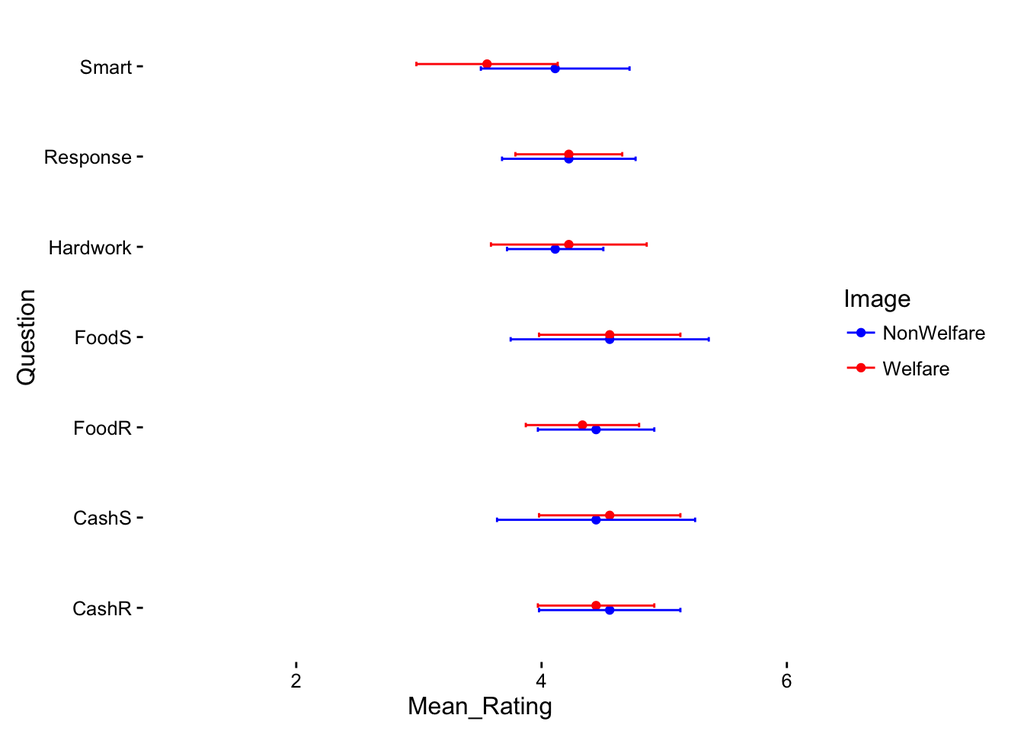

```r
ggplot(data = ms, aes(x = Question, y = Mean_Rating, ymin = 1, ymax = 6, colour = Image)) +
  geom_point(position = position_dodge(width = 0.1)) +
  geom_errorbar(aes(ymin=Mean_Rating-ci, ymax=Mean_Rating+ci),
    width=0.1, position=position_dodge(0.1)) +
  coord_flip() +
  scale_colour_manual(values = c("blue", "red")) +
  theme_classic()
```

### Data from replication of the original study (not the study the current study replicates because that data is not available online)

```r
d_rep = read.spss("Study3_SupportforWelfare (2).sav", to.data.frame=TRUE)
```

```r
tidy.d.rep <- d_rep %>%
  select(ID, Hardwork_W:CashS_NW, -starts_with("White")) %>%
  mutate_each(funs(as.numeric(., na.rm=TRUE)), contains("_W")) %>%
  mutate_each(funs(as.numeric(., na.rm=TRUE)), contains("_NW")) %>%
  gather(Hardwork_W:CashS_NW, key=Question, value=rating) %>%
    separate(Question, c("Question", "Image"), "_") %>%
  mutate(Image = fct_recode(Image, "NonWelfare"="NW", "Welfare"="W")) %>%
  na.omit()
length(unique(tidy.d.rep$ID))
```

```
## [1] 223
```

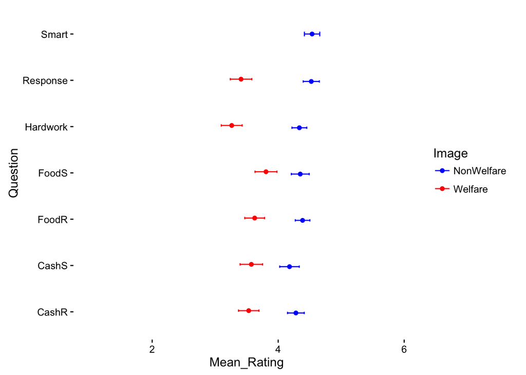

```r
ms.rep <- tidy.d.rep %>% # getting means
  group_by(Question, Image) %>% # it removes the last var granularity
  summarise(Mean_Rating = mean(rating, na.rm=TRUE), sd = sd(rating), sem = sem(rating), ci.lo = Mean_Rating - sem*1.96, ci.hi = Mean_Rating + sem*1.96, "ci"=ci(rating))
ms$Question = as.factor(ms$Question)

ggplot(data = ms.rep, aes(x = Question, y = Mean_Rating, ymin = 1, ymax = 6, colour = Image)) +
  geom_point(position = position_dodge(width = 0.1)) +
  geom_errorbar(aes(ymin=Mean_Rating-ci, ymax=Mean_Rating+ci),
    width=0.1, position=position_dodge(0.1)) +
  coord_flip() +
  scale_colour_manual(values = c("blue", "red")) +
  theme_classic()
```

# Recreation of original study

```r
d.study3 <- read_csv("Study3w1images.csv", na = c("", "NA"))
head(d)
```

```
## # A tibble: 6 × 77
##                  V1                   V2        V3    V4    V5
##               <chr>                <chr>     <chr> <chr> <chr>
## 1 R_3foScuskAC0bR5U Default Response Set Anonymous  <NA>  <NA>
## 2 R_3GBLCGVnnfnKOmG Default Response Set Anonymous  <NA>  <NA>
## 3 R_2VvzpabMYpjgm2W Default Response Set Anonymous  <NA>  <NA>
## 4 R_1rrea91BUvM95Ke Default Response Set Anonymous  <NA>  <NA>
## 5 R_2dyWmvHwGcIj9DX Default Response Set Anonymous  <NA>  <NA>
## 6 R_33jQPNzwltkFW1h Default Response Set Anonymous  <NA>  <NA>
## # ... with 72 more variables: V6 <chr>, V7 <int>, V8 <chr>, V9 <chr>,
## #   V10 <int>, welcome <int>, commitment <int>, name <chr>,
## #   introtxt <int>, White_Welfare <int>, Hardwork_W <int>, Smart_W <int>,
## #   Response_W <int>, FoodR_W <int>, FoodS_W <int>, CashR_W <int>,
## #   CashS_W <int>, White_NonWelfare <int>, Hardwork_NW <int>,
## #   Smart_NW <int>, Response_NW <int>, FoodR_NW <int>, FoodS_NW <int>,
## #   CashR_NW <int>, CashS_NW <int>, White_F1 <int>, Hardwork_F1 <int>,
## #   Smart_F1 <int>, Response_F1 <int>, FoodR_F1 <int>, FoodS_F1 <int>,
## #   CashR_F1 <int>, CashS_F1 <int>, White_F2 <int>, Hardwork_F2 <int>,
## #   Smart_F2 <int>, Response_F2 <int>, FoodR_F2 <int>, FoodR_F2_1 <int>,
## #   CashR_F2 <int>, CashS_F2 <int>, White_F3 <int>, Hardwork_F3 <int>,
## #   Smart_F3 <int>, Response_F3 <int>, FoodR_F3 <int>, FoodS_F3 <int>,
## #   CashR_F3 <int>, CashS_F3 <int>, White_F4 <int>, Hardwork_F4 <int>,
## #   Smart_F4 <int>, Response_F4 <int>, FoodR_F4 <int>, FoodS_F4 <int>,
## #   CashR_F4 <int>, CashS_F4 <int>, Demtxt <int>, Age <int>, Gender <int>,
## #   Ladder_72 <int>, Income <int>, Edu <int>, Ethnic <int>,
## #   PartyAff <int>, SocConserv <int>, EcoConserv <int>, thankyou <int>,
## #   Q125 <chr>, LocationLatitude <dbl>, LocationLongitude <dbl>,
## #   LocationAccuracy <int>
```

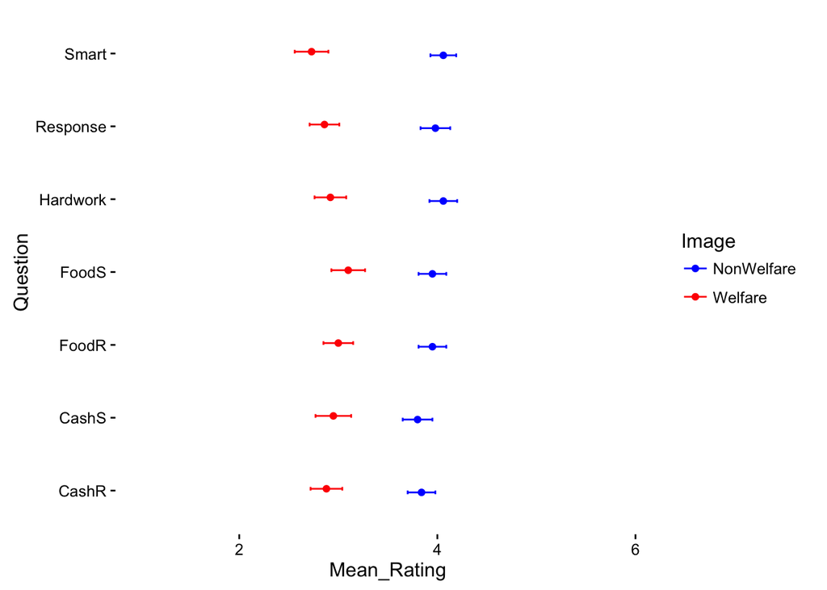

```r
ggplot(data = d.study3, aes(x = Question, y = Mean_Rating, ymin = 1, ymax = 6, colour = Image)) +
  geom_point(position = position_dodge(width = 0.1)) +
  geom_errorbar(aes(ymin=Mean_Rating-ci, ymax=Mean_Rating+ci),
    width=0.1, position=position_dodge(0.1)) +
  coord_flip() +
  scale_colour_manual(values = c("blue", "red")) +
  theme_classic()
```